# Build a stroke prediction model using R

Seungwoo Yu

2023-09-03

# About Data Analysis Report

This RMarkdown file contains the report of the data analysis done for the project on building and deploying a stroke prediction model in R. It contains analysis such as data exploration, summary statistics and building the prediction models. The final report was completed on Sun Sep 3 09:55:38 2023.

**Data Description:**

According to the World Health Organization (WHO) stroke is the 2nd leading cause of death globally, responsible for approximately 11% of total deaths.

This data set is used to predict whether a patient is likely to get stroke based on the input parameters like gender, age, various diseases, and smoking status. Each row in the data provides relevant information about the patient.

# Task One: Import data and data preprocessing

## Load data and install packages

```r
library(caret)
library(dplyr)
library(randomForest)
library(nnet)
library(MASS)
library(e1071)
library(tidymodels)
df <- read.csv('healthcare-dataset-stroke-data.csv')
head(df)
```

```
##      id gender age hypertension heart_disease ever_married     work_type
## 1  9046   Male  67            0             1          Yes       Private
## 2 51676 Female  61            0             0          Yes Self-employed
## 3 31112   Male  80            0             1          Yes       Private
## 4 60182 Female  49            0             0          Yes       Private
## 5  1665 Female  79            1             0          Yes Self-employed
## 6 56669   Male  81            0             0          Yes       Private
##   Residence_type avg_glucose_level  bmi  smoking_status stroke
## 1          Urban            228.69 36.6 formerly smoked      1
## 2          Rural            202.21  N/A    never smoked      1
## 3          Rural            105.92 32.5    never smoked      1
## 4          Urban            171.23 34.4          smokes      1
## 5          Rural            174.12   24    never smoked      1
## 6          Urban            186.21   29 formerly smoked      1
```

We see that there are some things that need to be remove such as id and need to remove N/A that appear

```r
str(df)
```

```
## 'data.frame':    5110 obs. of  12 variables:
##  $ id               : int  9046 51676 31112 60182 1665 56669 53882 10434 27419 60491 ...
##  $ gender           : chr  "Male" "Female" "Male" "Female" ...
##  $ age              : num  67 61 80 49 79 81 74 69 59 78 ...
##  $ hypertension     : int  0 0 0 0 1 0 1 0 0 0 ...
##  $ heart_disease    : int  1 0 1 0 0 0 1 0 0 0 ...
##  $ ever_married     : chr  "Yes" "Yes" "Yes" "Yes" ...
##  $ work_type        : chr  "Private" "Self-employed" "Private" "Private" ...
##  $ Residence_type   : chr  "Urban" "Rural" "Rural" "Urban" ...
##  $ avg_glucose_level: num  229 202 106 171 174 ...
##  $ bmi              : chr  "36.6" "N/A" "32.5" "34.4" ...
##  $ smoking_status   : chr  "formerly smoked" "never smoked" "never smoked" "smokes" ...
##  $ stroke           : int  1 1 1 1 1 1 1 1 1 1 ...
```

BMI is not an integer because of the N/A values and need to be changed to a numeric variable. Hypertension, heart_disease, and stroke need to be changed to character variable. Need to remove the first column of the data set as it is not used in our model and has no significance to the probability of having a stroke.

#### Changed bmi to numeric and tried to count how many N/A were in the dataset

```r
df$bmi <- as.numeric(df$bmi)
apply(X = is.na(df), MARGIN = 2, FUN = sum)
```

```
##                id            gender               age      hypertension
##                 0                 0                 0                 0
##     heart_disease      ever_married         work_type    Residence_type
##                 0                 0                 0                 0
## avg_glucose_level               bmi    smoking_status            stroke
##                 0               201                 0                 0
```

#### Missing N/A values were replaced with the mean of the BMI values for the model

```r
df$bmi[is.na(df$bmi)] <- mean(df$bmi, na.rm = TRUE)
```

#### Removed id column

```r
df <- df[,-1]
```

#### Convert 0s and 1s to No and Yes

```r
df$hypertension[df$hypertension == '0'] <- "No"
df$hypertension[df$hypertension == '1'] <- "Yes"
df$heart_disease[df$heart_disease == '0'] <- "No"
df$heart_disease[df$heart_disease == '1'] <- "Yes"
df$stroke[df$stroke == 1] <- "Yes"
df$stroke[df$stroke == 0] <- "No"
str(df)
```

```
## 'data.frame':    5110 obs. of  11 variables:
##  $ gender           : chr  "Male" "Female" "Male" "Female" ...
##  $ age              : num  67 61 80 49 79 81 74 69 59 78 ...
##  $ hypertension     : chr  "No" "No" "No" "No" ...
##  $ heart_disease    : chr  "Yes" "No" "Yes" "No" ...
##  $ ever_married     : chr  "Yes" "Yes" "Yes" "Yes" ...
##  $ work_type        : chr  "Private" "Self-employed" "Private" "Private" ...
##  $ Residence_type   : chr  "Urban" "Rural" "Rural" "Urban" ...
##  $ avg_glucose_level: num  229 202 106 171 174 ...
##  $ bmi              : num  36.6 28.9 32.5 34.4 24 ...
##  $ smoking_status   : chr  "formerly smoked" "never smoked" "never smoked" "smokes" ...
##  $ stroke           : chr  "Yes" "Yes" "Yes" "Yes" ...
```

#### Table columns to make sure there are no unwanted rows

```r
table(df$gender)
```

```
##
## Female   Male  Other
##   2994   2115      1
```

```r
table(df$hypertension)
```

```
##
##   No  Yes
## 4612  498
```

```r
table(df$heart_disease)
```

```
##
##   No  Yes
## 4834  276
```

```r
table(df$work_type)
```

```
##
##      children      Govt_job  Never_worked       Private Self-employed
##           687           657            22          2925           819
```

```r
table(df$Residence_type)
```

```
##
## Rural Urban
##  2514  2596
```

```r
table(df$smoking_status)
```

```
##
## formerly smoked    never smoked          smokes         Unknown
##             885            1892             789            1544
```

```r
table(df$ever_married)
```

```
##
##   No  Yes
## 1757 3353
```

```r
df <- subset(df, df$gender != 'Other')
write.csv(df, 'df.csv', row.names = FALSE)
```

## Describe and explore the data

#### Gender to Stroke Ratio

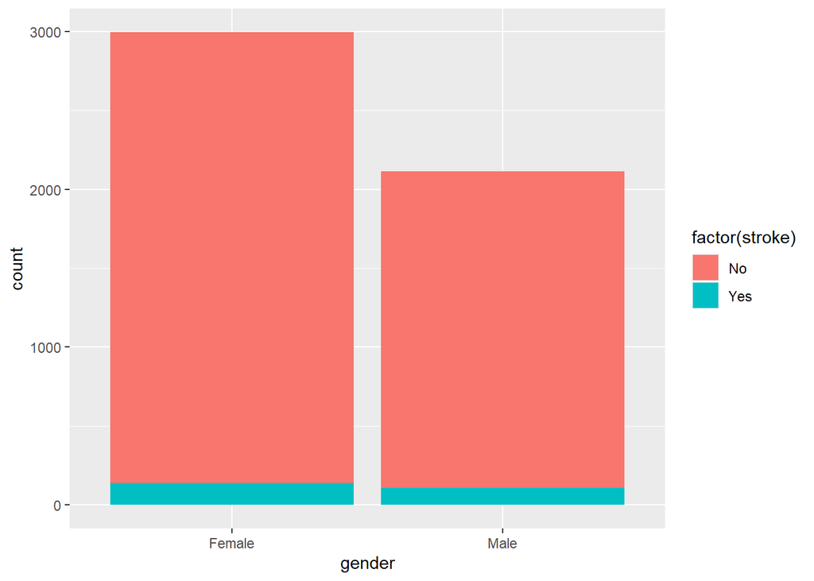

```r
ggplot(df, aes(x = gender, fill = factor(stroke))) +
  geom_bar()
```

We can see that from this data there is no difference between gender on who is more likely to get a stroke

#### Age to Stroke Ratio

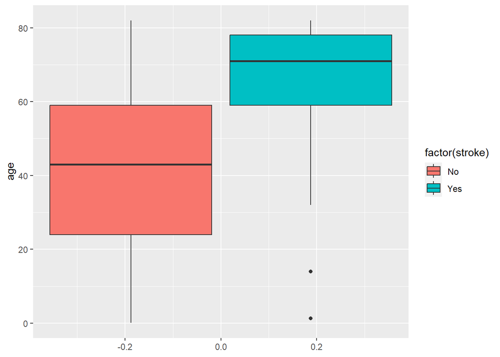

```r
ggplot(df, aes(y = age, fill= factor(stroke))) +
  geom_boxplot()
```

#### Hypertension to Stroke Ratio

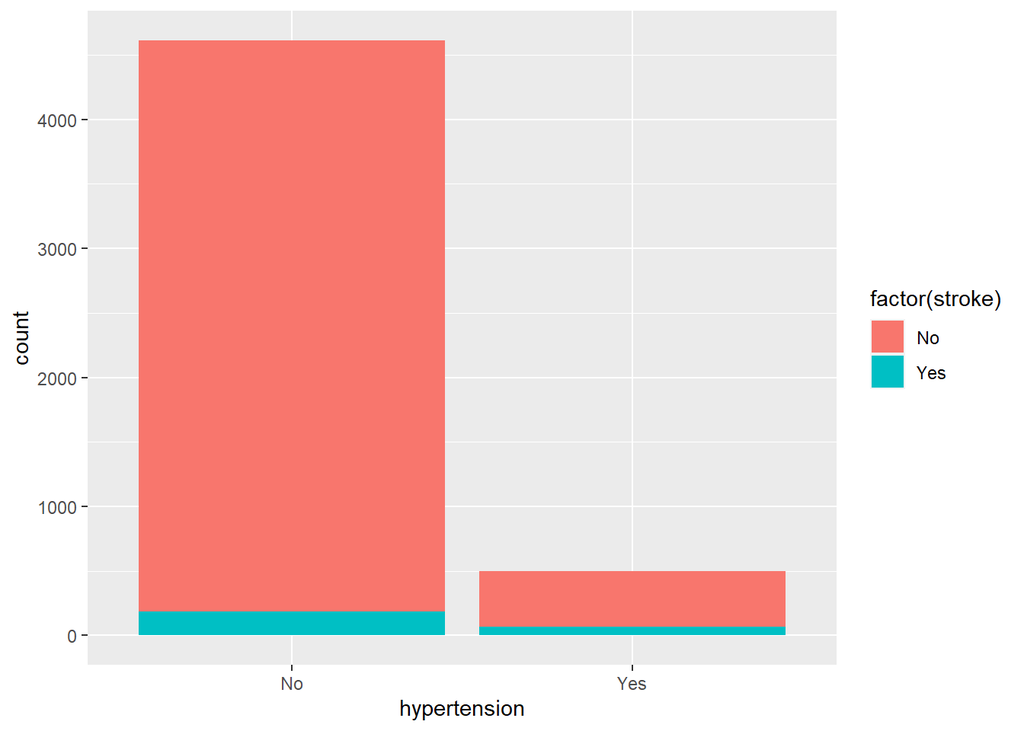

```r
ggplot(df, aes(x = hypertension, fill = factor(stroke))) +
  geom_bar()
```

#### Heart disease to Stroke Ratio

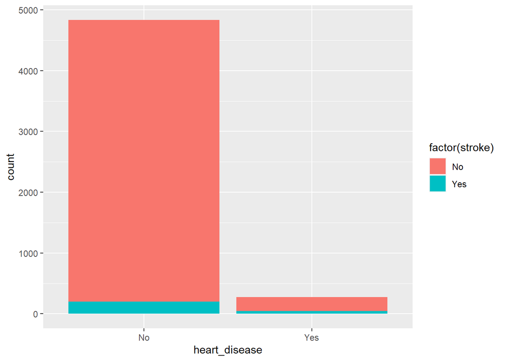

```r
ggplot(df, aes(x = heart_disease, fill = factor(stroke))) +
  geom_bar()
```

#### Married to Stroke Ratio

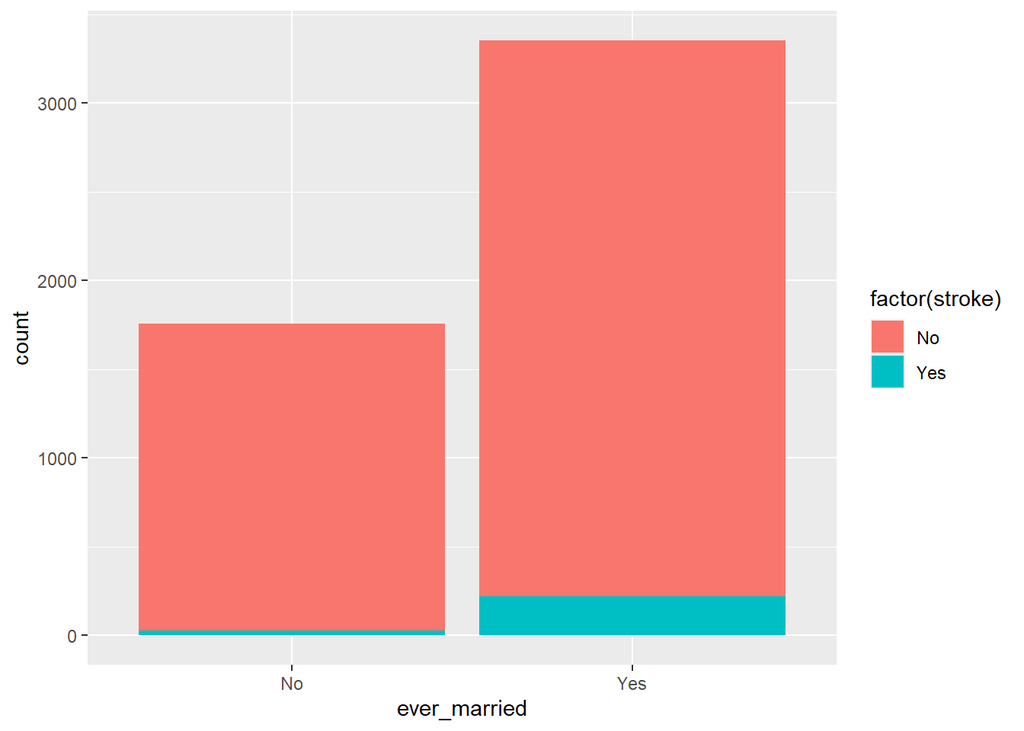

```r
ggplot(df, aes(x = ever_married, fill = factor(stroke))) +
  geom_bar()
```

#### Work type to Stroke Ratio

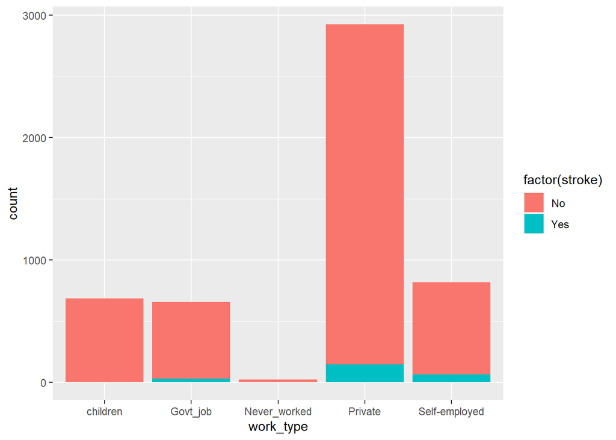

```r
ggplot(df, aes(x = work_type, fill = factor(stroke))) +
  geom_bar()
```

#### Residence Type

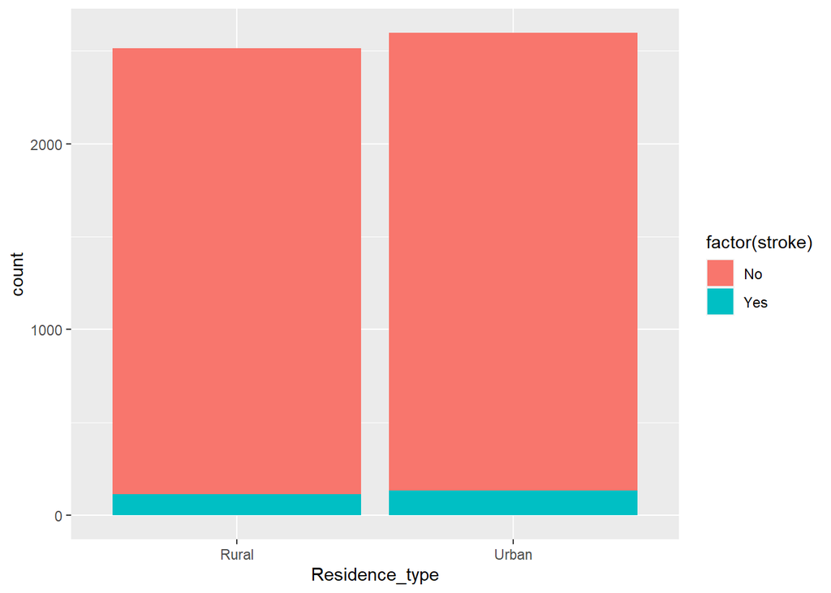

```r
ggplot(df, aes(x = Residence_type, fill = factor(stroke))) +
  geom_bar()
```

#### Glucose Level

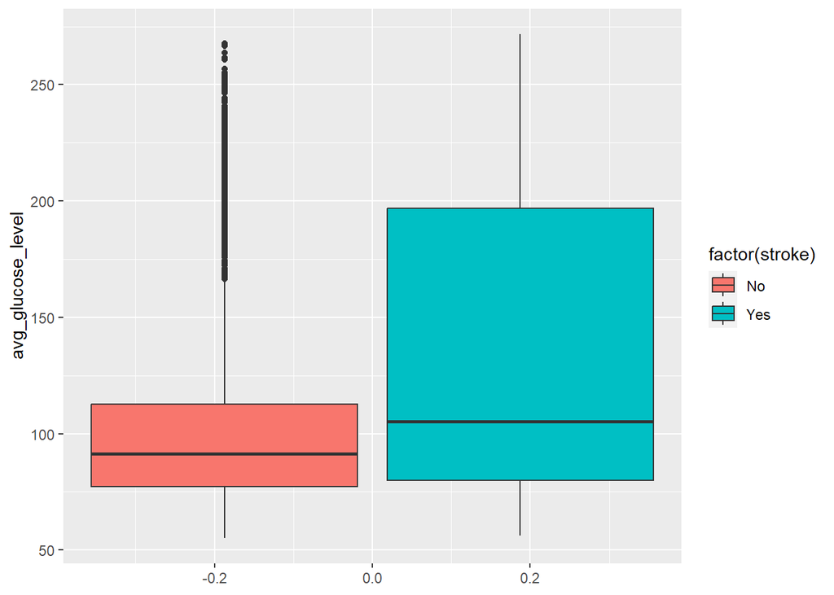

```r
ggplot(df, aes(y = avg_glucose_level, fill = factor(stroke))) +
  geom_boxplot()
```

#### Bmi Ratio

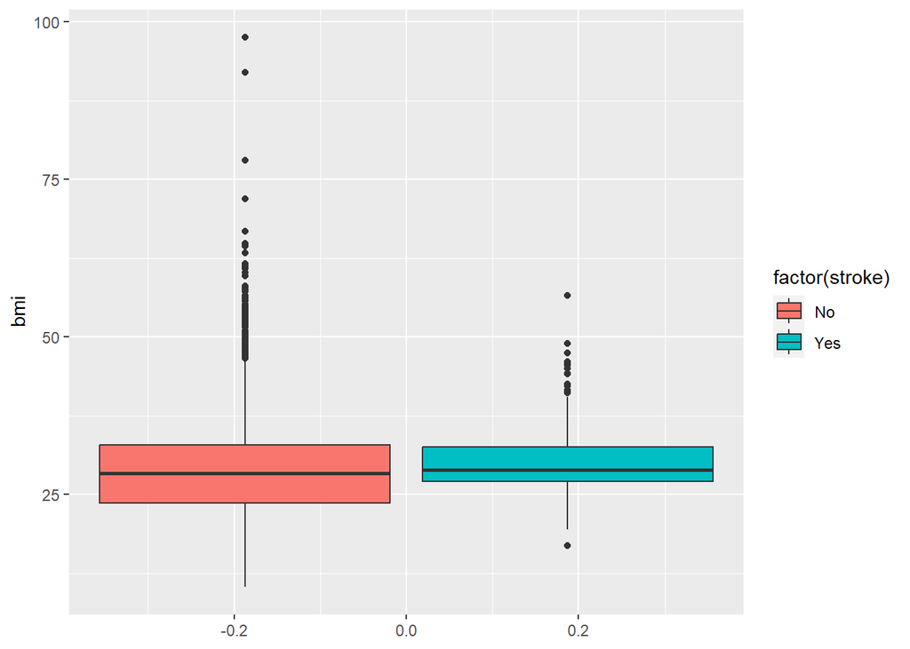

```r
ggplot(df, aes(y = bmi, fill = factor(stroke))) +
  geom_boxplot()
```

#### Smoking Ratio

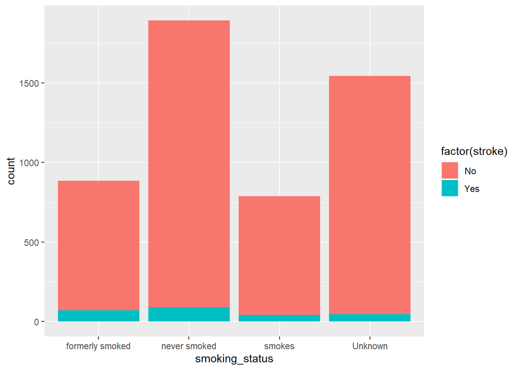

```r
ggplot(df, aes(x = smoking_status, fill = factor(stroke))) +
  geom_bar()
```

#### Set the stroke column as a Factor

```r
df['stroke'] <- lapply(df['stroke'], factor)
```

#### Intercept for the Model

```r
df_ratio <- glm(stroke~., df, family = 'binomial')
summary(df_ratio)
```

```
##
## Call:
## glm(formula = stroke ~ ., family = "binomial", data = df)
##
## Coefficients:
##                              Estimate Std. Error z value Pr(>|z|)
## (Intercept)                 -6.830176   0.786172  -8.688  < 2e-16 ***
## genderMale                   0.013534   0.141867   0.095 0.923998
## age                          0.074977   0.005842  12.834  < 2e-16 ***
## hypertensionYes              0.400601   0.164959   2.428 0.015162 *
## heart_diseaseYes             0.281022   0.191098   1.471 0.141411
## ever_marriedYes             -0.184642   0.225391  -0.819 0.412667
## work_typeGovt_job           -0.978971   0.836441  -1.170 0.241840
## work_typeNever_worked      -10.340873 309.249987  -0.033 0.973325
## work_typePrivate            -0.836153   0.820460  -1.019 0.308143
## work_typeSelf-employed      -1.213027   0.841190  -1.442 0.149292
## Residence_typeUrban          0.083365   0.138323   0.603 0.546719
## avg_glucose_level            0.003976   0.001199   3.317 0.000911 ***
## bmi                          0.003535   0.011288   0.313 0.754173
## smoking_statusnever smoked  -0.206054   0.175911  -1.171 0.241457
## smoking_statussmokes         0.113880   0.215347   0.529 0.596929
## smoking_statusUnknown       -0.072099   0.208368  -0.346 0.729331
## ---
## Signif. codes:  0 '***' 0.001 '**' 0.01 '*' 0.05 '.' 0.1 ' ' 1
##
## (Dispersion parameter for binomial family taken to be 1)
##
##     Null deviance: 1990.3  on 5108  degrees of freedom
## Residual deviance: 1581.1  on 5093  degrees of freedom
## AIC: 1613.1
##
## Number of Fisher Scoring iterations: 14
```

The glm() function was used as there are characters that are in the data. We see that the intercept if heavily skewed towards not having a stroke. The highest factor of having a stroke is hypertension with a coefficient of ~0.4. This will be used for the ratio of the dim factor when splitting the data into test and training splits

#### Ratio for train/test split

```r
ratio <- summary(df_ratio)$coefficients[4,1]
ratio
```

```
## [1] 0.4006006
```